# Ejemplo Metro SantiagoCL

Joshua Kunst

Sat Apr 29 20:30:16 2017

## Introducción

Ejercicio de manipulación de datos y visualización de datos de subidas de paraderos del metro de Santiago.

Se utilizará:

- `readr` para la lectura de datos.
- `dplyr` y `tidy` para manipulación de información.
- `ggplot2` para la visualización.
- `stringr` para tratamiento de strings.#’

## Cargando paquetes

```r
library(readr)
library(dplyr)
library(ggplot2)
library(hrbrthemes)
library(viridis)
library(stringr)
library(tidyr)
library(purrr)
```

## Estudiando las dubidad de

Los datos de _matrices de viaje son obtenidos de Directorio de Transporte Público: http://www.dtpm.gob.cl/index.php/2013-04-29-20-33-57/matrices-de-viaje.

```r
dfsubidas <- read_csv2("data/2015.04_Subidas_paradero_mediahora_web.csv")
```

Primera inspección;

```r
dfsubidas
```

```
## # A tibble: 358,543 × 3
##    paraderosubida mediahora subidas_laboral_promedio
##             <chr>    <time>                    <chr>
## 1       ALCANTARA  05:30:00       2.6000000000000000
## 2       ALCANTARA  06:00:00      13.2000000000000000
## 3       ALCANTARA  06:30:00      53.4000000000000000
## 4       ALCANTARA  07:00:00     184.8000000000000000
## 5       ALCANTARA  07:30:00     364.0000000000000000
## 6       ALCANTARA  08:00:00     546.2000000000000000
## 7       ALCANTARA  08:30:00     478.6000000000000000
## 8       ALCANTARA  09:00:00     359.0000000000000000
## 9       ALCANTARA  09:30:00     275.4000000000000000
## 10      ALCANTARA  10:00:00     229.6000000000000000
## # ... with 358,533 more rows
```

La tabla contiene información de subidas promedios en días laborales por cada media hora. La variable `subidas_laboral_promedio` se ha cargado como carácter en lugar de numérica.

```r
dfsubidas <- mutate(dfsubidas, subidas_laboral_promedio = as.numeric(subidas_laboral_promedio))
dfsubidas
```

```
## # A tibble: 358,543 × 3
##    paraderosubida mediahora subidas_laboral_promedio
##             <chr>    <time>                    <dbl>
## 1       ALCANTARA  05:30:00                      2.6
## 2       ALCANTARA  06:00:00                     13.2
## 3       ALCANTARA  06:30:00                     53.4
## 4       ALCANTARA  07:00:00                    184.8
## 5       ALCANTARA  07:30:00                    364.0
## 6       ALCANTARA  08:00:00                    546.2
## 7       ALCANTARA  08:30:00                    478.6
## 8       ALCANTARA  09:00:00                    359.0
## 9       ALCANTARA  09:30:00                    275.4
## 10      ALCANTARA  10:00:00                    229.6
## # ... with 358,533 more rows
```

Cuantos paraderos contiene la tabla:

```r
count(dfsubidas, paraderosubida)
```

```
## # A tibble: 11,222 × 2
##              paraderosubida     n
##                       <chr> <int>
## 1                         -    45
## 2                 ALCANTARA    37
## 3              BAQUEDANO L1    37
## 4              BAQUEDANO L5    36
## 5                 BARRANCAS    37
## 6              BELLAS ARTES    37
## 7  BELLAVISTA DE LA FLORIDA    37
## 8                BLANQUEADO    37
## 9               CAL Y CANTO    36
## 10          CAMINO AGRICOLA    37
## # ... with 11,212 more rows
```

Contiene 11222. Filtramos solamente paradas de metro.

```r
set.seed(1234)
sample(dfsubidas$paraderosubida, 20)
```

```
##  [1] "L-13-3-35-SN"   "L-8-22-10-NS"   "L-7-45-6-SN"    "L-8-32-5-NS"
##  [5] "T-27-224-NS-15" "PEDRERO"        "E-20-189-PO-5"  "L-21-18-20-OP"
##  [9] "T-11-83-SN-10"  "L-34-40-50-PO"  "T-13-97-SN-35"  "L-34-7-60-OP"
## [13] "L-23-36-15-SN"  "T-33-264-SN-30" "L-23-6-20-OP"   "T-23-376-NS-7"
## [17] "L-23-4-25-PO"   "L-2-26-10-NS"   "L-17-42-5-NS"   "L-21-18-10-PO"
```

Luego de explorar un poco está columna se selecciona lo que **no** posea un string que comience con T, L, I o E y un guión:

```r
dfsubidas <- filter(dfsubidas, !str_detect(paraderosubida, "^(T|L|I|E)?-"))
count(dfsubidas, paraderosubida)
```

```
## # A tibble: 106 × 2
##              paraderosubida     n
##                       <chr> <int>
## 1                 ALCANTARA    37
## 2              BAQUEDANO L1    37
## 3              BAQUEDANO L5    36
## 4                 BARRANCAS    37
## 5              BELLAS ARTES    37
## 6  BELLAVISTA DE LA FLORIDA    37
## 7                BLANQUEADO    37
## 8               CAL Y CANTO    36
## 9           CAMINO AGRICOLA    37
## 10        CARLOS VALDOVINOS    37
## # ... with 96 more rows
```

Y luego del filtros nos quedamos con 106 estaciones (de metro supuestamente). Sin embargo vemos que aparece *Baquedano* dos veces dado que es una estación de combinación. En esta oportunidad la consideraremos como una por lo que al nomnre de la estación removeremos la parte que hace distición a que línea es `" L\\d"` donde `"\\d"` es algún número.

Entonces removemos, agrupamos para sumar los casos de combinaciones:

```r
dfsubidas <- dfsubidas %>%
  mutate(paraderosubida = str_replace(paraderosubida, " L\\d$", "")) %>%
  group_by(paraderosubida, mediahora) %>%
  summarise(subidas_laboral_promedio = sum(subidas_laboral_promedio)) %>%
  ungroup()

count(dfsubidas, paraderosubida)
```

```
## # A tibble: 101 × 2
##              paraderosubida     n
##                       <chr> <int>
## 1                 ALCANTARA    37
## 2                 BAQUEDANO    37
## 3                 BARRANCAS    37
## 4              BELLAS ARTES    37
## 5  BELLAVISTA DE LA FLORIDA    37
## 6                BLANQUEADO    37
## 7               CAL Y CANTO    36
## 8           CAMINO AGRICOLA    37
## 9         CARLOS VALDOVINOS    37
## 10              CEMENTERIOS    37
## # ... with 91 more rows
```

;)!.

Ahora contemos si todas las estaciones contiene la misma cantidad de registros

```r
dfsubidas %>%
  count(paraderosubida) %>%
  count(n)
```

```
## # A tibble: 3 × 2
##       n    nn
##   <int> <int>
## 1    36    38
## 2    37    62
## 3    38     1
```

Existe una estación que contiene 38 registros y otras 38 estaciones que contiene 36 regitros.

```r
dfsubidas %>%
  count(mediahora)
```

```
## # A tibble: 38 × 2
##    mediahora     n
##       <time> <int>
## 1   00:00:00     1
## 2   05:30:00   101
## 3   06:00:00   101
## 4   06:30:00   101
## 5   07:00:00   101
## 6   07:30:00   101
## 7   08:00:00   101
## 8   08:30:00   101
## 9   09:00:00   101
## 10  09:30:00   101
## # ... with 28 more rows
```

```r
dfsubidas %>%
  count(mediahora) %>%
  filter(n != 101)
```

```
## # A tibble: 2 × 2
##   mediahora     n
##      <time> <int>
## 1  00:00:00     1
## 2  23:30:00    63
```

```r
# Eliminaremos las 12AM.
dfsubidas <- filter(dfsubidas, mediahora != 0)

# dfsubidas <- complete(dfsubidas, paraderosubida, mediahora,
                 # fill = list(subidas_laboral_promedio = 0))
```

Ahora visualizaremos los registros por líneas y veremos la tencendia a través de un suavizamientos:

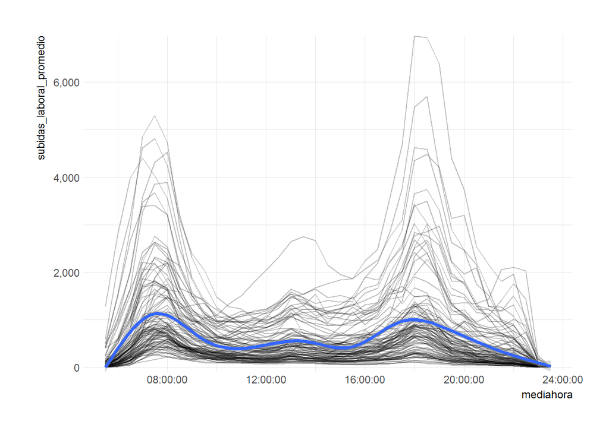

```r
gg <- ggplot(dfsubidas) +
  geom_line(aes(mediahora, subidas_laboral_promedio,
                group = paraderosubida), alpha = 0.25) +
  geom_smooth(aes(mediahora, subidas_laboral_promedio), size = 1.3) +
  scale_x_time() +
  scale_y_comma()
gg
```

Se observa lo esperado: mucha gente ingresa a las 8 y 18.30 app además de un leve peak a las 13.00 horas.

Por diversión agregaremos las horas puntas:

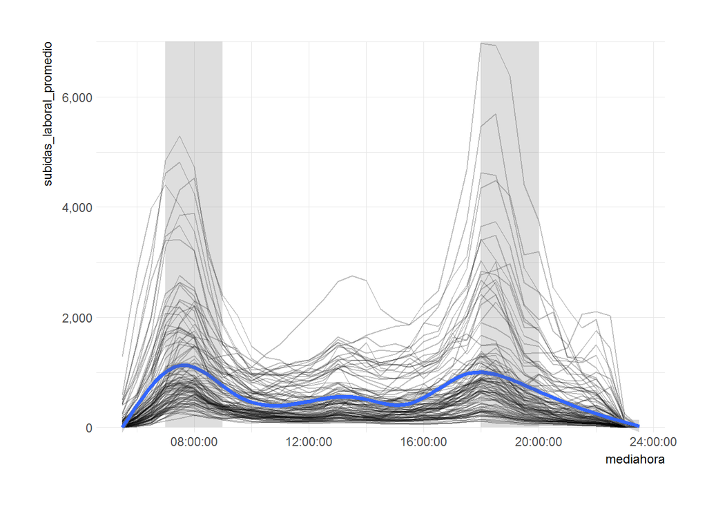

```r
library(lubridate)

dfhorarios <- data_frame(
  xmin = c(hms("7:00:00"), hms("18:00:00")),
  xmax = c(hms("8:59:59"), hms("19:59:69")),
  ymin = c(0, 0),
  ymax = rep(7000, 2),
  g = c(1, 2)
)

gg <- gg +
  geom_rect(data = dfhorarios,
            aes(xmin = xmin, xmax = xmax,
                ymin = ymin, ymax = ymax), alpha = 0.2)

gg
```

## Agrupando Estaciones

```r
dfsubidas2 <- spread(dfsubidas, mediahora, subidas_laboral_promedio)
dfsubidas2
```

```
## # A tibble: 101 × 38
##              paraderosubida `05:30:00` `06:00:00` `06:30:00` `07:00:00`
## *                     <chr>      <dbl>      <dbl>      <dbl>      <dbl>
## 1                 ALCANTARA        2.6       13.2       53.4      184.8
## 2                 BAQUEDANO       88.0      132.6      234.6      493.4
## 3                 BARRANCAS       37.0      195.4      406.4      736.8
## 4              BELLAS ARTES        6.6       37.0       92.2      177.6
## 5  BELLAVISTA DE LA FLORIDA      157.6      297.8      565.8     1113.6
## 6                BLANQUEADO       35.8      199.6      411.4      646.4
## 7               CAL Y CANTO      103.0      575.2     1281.0     2309.0
## 8           CAMINO AGRICOLA       38.2      113.2      281.6      530.6
## 9         CARLOS VALDOVINOS       46.2      113.0      210.4      342.4
## 10              CEMENTERIOS       20.8       78.4      167.6      249.8
## # ... with 91 more rows, and 33 more variables: `07:30:00` <dbl>,
## #   `08:00:00` <dbl>, `08:30:00` <dbl>, `09:00:00` <dbl>,
## #   `09:30:00` <dbl>, `10:00:00` <dbl>, `10:30:00` <dbl>,
## #   `11:00:00` <dbl>, `11:30:00` <dbl>, `12:00:00` <dbl>,
## #   `12:30:00` <dbl>, `13:00:00` <dbl>, `13:30:00` <dbl>,
## #   `14:00:00` <dbl>, `14:30:00` <dbl>, `15:00:00` <dbl>,
## #   `15:30:00` <dbl>, `16:00:00` <dbl>, `16:30:00` <dbl>,
## #   `17:00:00` <dbl>, `17:30:00` <dbl>, `18:00:00` <dbl>,
## #   `18:30:00` <dbl>, `19:00:00` <dbl>, `19:30:00` <dbl>,
## #   `20:00:00` <dbl>, `20:30:00` <dbl>, `21:00:00` <dbl>,
## #   `21:30:00` <dbl>, `22:00:00` <dbl>, `22:30:00` <dbl>,
## #   `23:00:00` <dbl>, `23:30:00` <dbl>
```

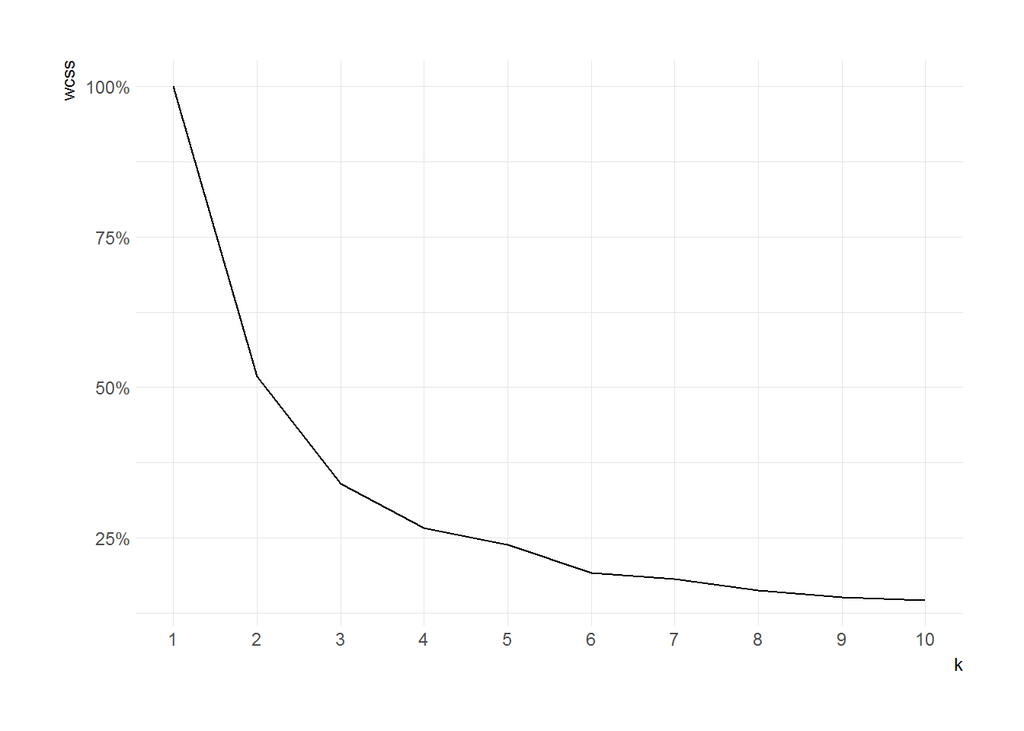

```r
dfsubidas3 <- select(dfsubidas2, -1) %>%
  mutate_all(function(x) ifelse(is.na(x), 0, x)) %>%
  mutate_all(scale)

kmeans <- map_df(1:10, function(k){ # k <- 6
  set.seed(123)
  kmod <- kmeans(dfsubidas3, centers = k)
  data_frame(k = k, wcss = 1 - kmod$betweenss/kmod$totss, kmod = list(kmod))
})

ggplot(kmeans) +
  geom_line(aes(k, wcss)) +
  scale_y_continuous(labels = scales::percent) +
  scale_x_continuous(breaks = seq(1:10), minor_breaks = NULL)
```

```r
K <- 4

dfsubidas2 <- mutate(dfsubidas2, grupo = kmeans$kmod[[K]]$cluster)

dfsubidas <- left_join(dfsubidas, select(dfsubidas2, paraderosubida, grupo))
dfsubidas
```

```
## # A tibble: 3,699 × 4
##    paraderosubida mediahora subidas_laboral_promedio grupo
##             <chr>    <time>                    <dbl> <int>
## 1       ALCANTARA  05:30:00                      2.6     3
## 2       ALCANTARA  06:00:00                     13.2     3
## 3       ALCANTARA  06:30:00                     53.4     3
## 4       ALCANTARA  07:00:00                    184.8     3
## 5       ALCANTARA  07:30:00                    364.0     3
## 6       ALCANTARA  08:00:00                    546.2     3
## 7       ALCANTARA  08:30:00                    478.6     3
## 8       ALCANTARA  09:00:00                    359.0     3
## 9       ALCANTARA  09:30:00                    275.4     3
## 10      ALCANTARA  10:00:00                    229.6     3
## # ... with 3,689 more rows
```

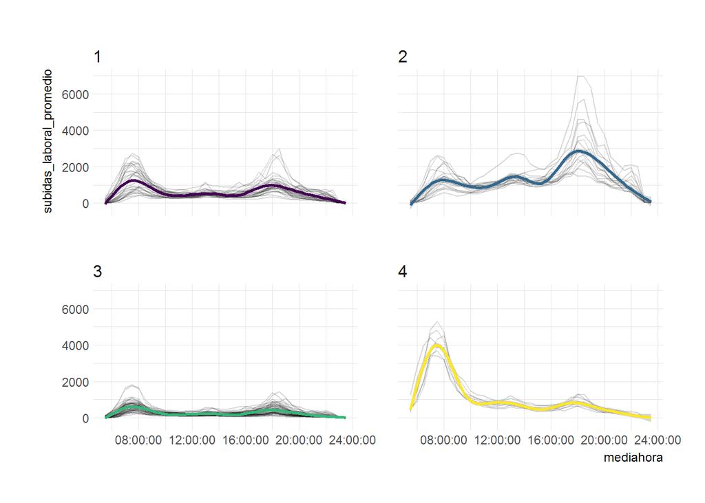

```r
ggplot(dfsubidas, aes(mediahora, subidas_laboral_promedio)) +
  geom_line(aes(group = paraderosubida), alpha = 0.15) +
  geom_smooth(aes(group = grupo, color = factor(grupo))) +
  scale_color_viridis(discrete = TRUE) +
  scale_x_time() +
  facet_wrap(~grupo) +
  theme(legend.position = "none")
```

## Geográficamente

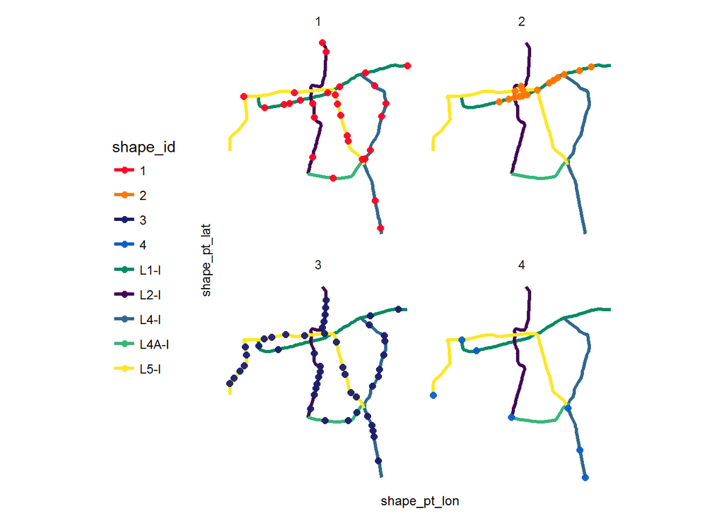

```r
routes <- read_csv("data/routes.txt")
trips <- read_csv("data/trips.txt")
stops <- read_csv("data/stops.txt")
shapes <-read_csv("data/shapes.txt")

stops_metro <- stops %>%
  filter(!grepl("\\d", stop_id)) %>%
  mutate(stop_url = basename(stop_url))

routes_metro <- filter(routes, grepl("^L\\d",route_id))

shapes_metro <- routes %>%
  filter(grepl("^L\\d",route_id)) %>%
  semi_join(trips, .) %>%
  semi_join(shapes, .) %>%
  ### IMPORTANTE
  filter(str_detect(shape_id, "-I")) %>%
  mutate(shape_id2 = str_replace(shape_id, "-I", ""))

colors_metro <- distinct(shapes, shape_id) %>%
  left_join(distinct(trips, shape_id, route_id)) %>%
  left_join(distinct(routes, route_id, route_color)) %>%
  semi_join(shapes_metro) %>%
  mutate(route_color = paste0("#", route_color))

str_to_id2 <- function(x) {
  x %>%
    str_trim() %>%
    str_to_lower() %>%
    str_replace_all("\\s+", "_") %>%
    str_replace_all("\\s+de\\s+", "") %>%
    str_replace_all("á", "a") %>%
    str_replace_all("é", "e") %>%
    str_replace_all("í", "i") %>%
    str_replace_all("ó", "o") %>%
    str_replace_all("ú", "u") %>%
    str_replace_all("ñ", "n") %>%
    str_replace_all("`", "") %>%
    str_replace_all("_de_", "_") %>%
    str_replace_all("rondizonni", "rondizzoni")
}

dfsubidas2 <- mutate(dfsubidas2, id = str_to_id2(paraderosubida))

stops_metro_data <- stops_metro %>%
  mutate(id = str_to_id2(stop_name)) %>%
  left_join(select(dfsubidas2, grupo, id))

ggplot()+
  geom_path(data = shapes_metro,
            aes(x = shape_pt_lon, y = shape_pt_lat, group = shape_id, color = shape_id),
            size = 1.2) +

  geom_point(data = stops_metro_data,
             aes(x = stop_lon, y = stop_lat, color = factor(grupo)),
             size = 2, alpha = 0.95) +

  scale_color_manual(values = c(colors_metro$route_color, viridis(K))) +
  # scale_color_viridis(discrete = TRUE) +
  facet_wrap(~grupo) +
  scale_x_continuous(breaks = NULL) +
  scale_y_continuous(breaks = NULL) +
  coord_fixed() +
  theme_minimal() +
  theme(legend.position = "left")
```